# Project 2: Lmoment Diagrams and Probability Plots

Kevin M. Smith

October 29, 2014

## EDA

#### Import Libraries

```r
require(devtools)   # Automates compiling from GitHub repository.
require(RCurl)      # Allows remote data downloading.
require(ggplot2)    # Graphics Package
require(reshape)    # Data Frame Toolset
require(MASS)       # Support Functions
```

#### Download Data

```r
data <- read.csv(
  text = getURL(paste("https://raw.githubusercontent.com/",
                "Kevin-M-Smith/202-P2/master/data/data.csv", sep = "")), header=FALSE)

head(data)
```

```
##       V1     V2     V3     V4     V5     V6     V7     V8     V9    V10
## 1 10.740  8.803  4.867  5.003 12.511 21.125  7.984  6.907 11.229 11.657
## 2 18.234  9.359  8.185  4.096 10.209  4.624 10.369  8.388  5.557 14.061
## 3  6.824 13.258 16.829 11.363  6.707  4.172 24.166  9.240  7.394 19.352
## 4  3.865  2.058 10.557  3.406 15.467 13.657  5.535  8.455  8.323  7.845
## 5 13.683 10.961  8.758  7.369  8.244 15.944  4.700  5.278  7.968  5.659
## 6 12.512  3.518  6.355  6.272  8.167  5.699  5.754 16.477  6.828  6.469
```

### Density Curves

Histograms are always a great place to start. However, binning is can be an issue, especially with small sample sizes. It is sometimes easier to visualize the distribution by plotting the data with **emprical density curve**. These are basically histograms that have been **smoothed using a kernel function**. Here gaussian smoothing is employed, it is the default. There is **one colored curve for each of the 10 samples**. The **black curve gives the pooled density**. A series of simple horizontal boxplots is also plotted below for comparison. For brevity, the boxplot code is hidden.

[figure not shown]

```r
frames = c(seq(0.01, 0.2, 0.02), rep(0.2, 12), seq(0.2, 0.01, -0.02), rep(0.01, 12))
df <- melt(data)
for(i in frames){
  p <- ggplot(df, aes(value)) + geom_density(fill = "black")
  p <- p + xlim(min(df$value), max(df$value)) + theme_bw() + theme(legend.position="none")
  p <- p + geom_density(aes(value, fill=variable), alpha = i)
  print(p)
}
```

#### Maximum Likelihood Estimators

The function below provides stable maximum likelihood parameter estimates for the following distributions:

- unif : uniform
- norm : normal
- lnorm : 2-parameter lognormal
- lnorm3 : 3-parameter lognormal
- exp : 1-parameter exponential
- gamma : 2-parameter gamma
- gamma3 : 3-parameter gama
- weibull : weibull
- gumbel : gumbel
- gev : generalized extreme value

```r
library(fitdistrplus)
library(ordinal)
library(evd)
library(FAdist)

stable = c("unif", "norm", "lnorm", "lnorm3", "exp", "gamma", "gamma3", "weibull", "gumbel", "gev")

# Enforce evd namespace since there are multiple gev functions at play.
pgev = evd::pgev; rgev = evd::rgev; dgev = evd::dgev; qgev = evd::qgev

mleFit <- function(name, x){
  fit <- switch(name,
                lnorm3 = {
                  fitdist(x, name, start = list(
                    shape = log((mean(x)^2) / sqrt(var(x) + mean(x))),
                    scale = log(1+(var(x)/(mean(x)^2))),
                    thres = -0.1))
                  },
                gamma3 = {
                  fitdist(x, name, start = list(
                    shape = mean(x)^2 / var(x),
                    scale = var(x) / mean(x),
                    thres = -0.1))
                  },
                gumbel = {
                  fitdist(x, "gev", start = as.list(fgev(df$value)$estimate[1:2]),
                          fix.arg = list(shape = 0))
                  },
                gev = {
                  fitdist(x, name, start = as.list(fgev(df$value)$estimate))
                  },
                exp2 = {
                  fitdist(x, name, start = list(
                    rate = 1 / mean(x),
                    thres = -5))
                  },
                {
                  fitdist(x, name)
                  }
                )
  }
```

### Comparative Density Curves

Utilizing the MLE estimator function developed above, we can plot the empirical and theoretical density curves against one another.

```r
doubleDensity <- function(name){
  fit <- mleFit(name = name, x = df$value)
  parameters <- c(as.list(fit$estimate))
  #parameters <-  c(as.list(fit$estimate), as.list(fit$fix.arg))
  interval <- seq(0, 30, 0.01)
  density <- do.call(paste("d", name, sep=""), c(list(x=interval), as.list(parameters)))
  p <- ggplot(df, aes(value)) + geom_density(fill = "black", alpha = 0.5)
  p <- p + ylim(0, 0.12) + xlim(min(df$value), max(df$value)) + theme_bw()
  p <- p + annotate("ribbon", x = interval, ymax = density,
                    ymin = 0, fill = "#E69F00", col = "#E69F00", alpha = 0.5)
  p <- p + annotate("text", x = 18, y = 0.075, label = paste(name, "distribution"), size=10)
  print(p)
  p
}

dd <- lapply(stable, doubleDensity)
```

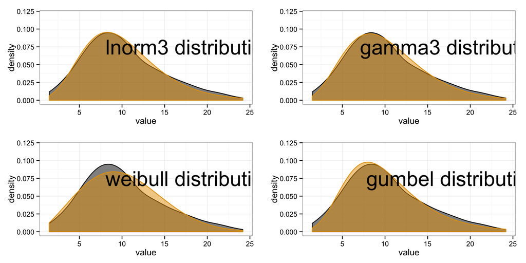

```r
library(gridExtra); grid.arrange(dd[[4]],  dd[[7]], dd[[8]], dd[[9]],nrow = 2)
```

## L-moments in R

### Revising the ‘lmon’ Package

The lmom package for R is developed an maintained by Jonathan Hosking at IMB Research. The package is very powerful and straight forward to use. It computes both empirical and theoretical L-moments and includes functions for plotting L-moment ratio diagrams. However the lmom package only provides an interface for producing *L*-Kurtosis vs. *L*-Skew moment ratio diagrams. This limits the utility for determining sample data fits to lower-order distributions. **I augmented the lmon library to fit 2-parameter distributions, with the hope that it can become its own CRAN package, or merged with the offiical lmon library.**

### L-CV vs. L-Skew

After **Vogel and Wilson 1996**, relationships between *L*-CV and *L*-Skew can be developed for several two-parameter distributions as shown below.

```r
t3 = seq(-1, 1, 0.01)
LN2 = 1.16008*t3 - 0.05325*t3^2 - 0.10501*t3^4 - 0.00103*t3^6
GA2 = 1.74139*t3 - 2.59736*t3^2 + 2.09911*t3^4 - 0.35948*t3^6
WB2 = 0.17864 + 1.02381*t3 - 0.17878*t3^2 - 0.00894*t3^4 - 0.01443*t3^6
GP2 = 0.33299 + 0.44559*t3 + 0.16641*t3^2 + 0.09111*t3^5 - 0.03625*t3^7

out = data.frame(
  tau_3 = t3,
  LN2 = LN2,
  GA2 = GA2,
  WB2 = WB2,
  GP2 = GP2)

head(out)
```

```
##   tau_3       LN2       GA2        WB2          GP2
## 1 -1.00 -1.319370 -2.599120 -1.0473200 -0.001050000
## 2 -0.99 -1.302511 -2.591695 -1.0323275  0.002097006
## 3 -0.98 -1.285790 -2.583357 -1.0174228  0.005245291
## 4 -0.97 -1.269203 -2.574114 -1.0026041  0.008392990
## 5 -0.96 -1.252748 -2.563975 -0.9878696  0.011538421
## 6 -0.95 -1.236423 -2.552951 -0.9732175  0.014680071
```

### Demonstrating use of the lmon library.

#### Import Libraries

```r
# install.packages("devtools", "RCurl")   # Download libraries from CRAN if Necessary
# install_github("Kevin-M-Smith/lmom")    # Download & compile customized lmom library.
require(lmom)                             # Load custom lmom library.

                                          # If you already have lmom installed,
                                          # you must remove it
```

#### Use the lmon library to get empirical L-moments.

```r
lmr <- apply(data, 2, samlmu, 4)
lmr[,1:6]
```

```
##            V1         V2          V3        V4        V5         V6
## l_1 9.7970800 8.90320000 10.09580000 8.8728400 9.9818000 10.6170400
## l_2 2.4212667 2.41691333  2.45190667 2.8400167 2.5952633  2.5779500
## t_3 0.2280563 0.04680242  0.05528688 0.1626970 0.1654457  0.1402127
## t_4 0.1257835 0.17675885  0.12455729 0.1038221 0.1133603  0.1199525
```

#### We need to transpose the data before plotting.

```r
t(lmr)
```

```
##          l_1      l_2        t_3        t_4
## V1   9.79708 2.421267 0.22805634 0.12578348
## V2   8.90320 2.416913 0.04680242 0.17675885
## V3  10.09580 2.451907 0.05528688 0.12455729
## V4   8.87284 2.840017 0.16269699 0.10382211
## V5   9.98180 2.595263 0.16544572 0.11336027
## V6  10.61704 2.577950 0.14021269 0.11995253
## V7  11.39700 3.816827 0.18060598 0.02731516
## V8  11.47420 2.361890 0.13826307 0.01646705
## V9   9.77048 2.120493 0.20652290 0.21018895
## V10 10.22236 2.005550 0.08930370 0.11305978
```

#### Plot *L*-CV vs. *L*-Skew

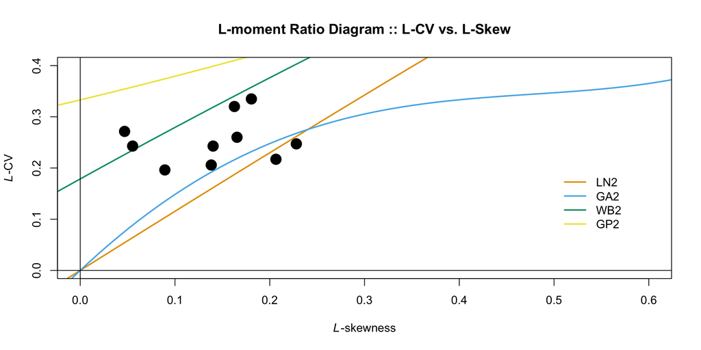

```r
lmrd2(t(lmr),
      main = "L-moment Ratio Diagram :: L-CV vs. L-Skew",
      pch.data=19, cex.data = 2,
      lwd = 2, col = c("#E69F00", "#56B4E9", "#009E73",
                       "#F0E442", "#0072B2", "#D55E00", "#CC79A7"),
      xlegend=0.5, ylegend=0.2)
```

#### Plot *L*-Kurtosis vs. *L*-Skew

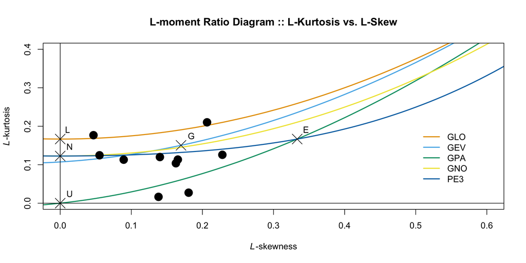

```r
lmrd(t(lmr),
     main = "L-moment Ratio Diagram :: L-Kurtosis vs. L-Skew",
     lwd = 2, col = c("#E69F00", "#56B4E9", "#009E73",
                      "#F0E442", "#0072B2", "#D55E00", "#CC79A7"),
     pch.data = 19, cex.data = 2,
     pch.dist = 4, col.dist = "black", cex.dist = 2.5,
     xlegend = 0.5, ylegend=0.2)
```

### The Bootstrap

```r
m = 10000; n = 25
resample <- function(i) df$value[floor(runif(n, 1, 250))]


bootstrap = lapply(1:m, resample)
lmr <- lapply(bootstrap, samlmu, 4)
lmr <- matrix(unlist(lmr), nrow = 4,
              dimnames=list(c("l_1", "l_2", "t_3", "t_4"), NULL))
```

```r
lmrd2.p <- function(x){
  lmrd2(x, main = "L-moment Ratio Diagram :: L-CV vs. L-Skew",
     lwd = 2, col = rep("#44444444", 10),
     pch.data = 19, cex.data = 0.1,
     xlegend = 0.5, ylegend=0.2)
}

for(i in 1:(m/1000)) lmrd2.p(t(lmr[,1:(i*1000)]))
```

[output not shown]

```r
L.cv <- lmr[2,] / lmr[1,]
L.sk <- lmr[3,]
d <- kde2d(L.sk, L.cv)

for(i in 1:10){
    lmrd2.p(t(lmr[,1:(m-i)]))

    contour(d, drawlabels=FALSE, nlevels=7, lwd=3,
        col=c("#999999", "#56B4E9", "#009E73", "#F0E442", "#0072B2", "#D55E00", "#CC79A7"), add=TRUE)

    #abline(v=c(mean(L.sk), median(L.sk)), h=c(mean(L.cv), median(L.cv)), lwd=2, lty=c(1,2))
}
```

[output not shown]

```r
lmrd.p <- function(x){
  lmrd(x, main = "L-moment Ratio Diagram :: L-Kurtosis vs. L-Skew",
     lwd = 2, col = rep("#44444444", 10),
     pch.data = 19, cex.data = 0.1,
     pch.dist = 19, col.dist = "#E69F00", cex.dist = 3,
     xlegend = 0.5, ylegend=0.2)
}

for(i in 1:(m/1000)) lmrd.p(t(lmr[,1:(i*1000)]))
```

[output not shown]

```r
L.kt <- lmr[4,]
L.sk <- lmr[3,]
d <- kde2d(L.sk, L.kt)

for(i in 1:10){
    lmrd.p(t(lmr[,1:(m-i)]))

    contour(d, drawlabels=FALSE, nlevels=7, lwd=3,
        col=c("#999999", "#56B4E9", "#009E73", "#F0E442", "#0072B2", "#D55E00", "#CC79A7"), add=TRUE)

    #abline(v=c(mean(L.sk), median(L.sk)), h=c(mean(L.cv), median(L.cv)), lwd=2, lty=c(1,2))
}
```

[output not shown]

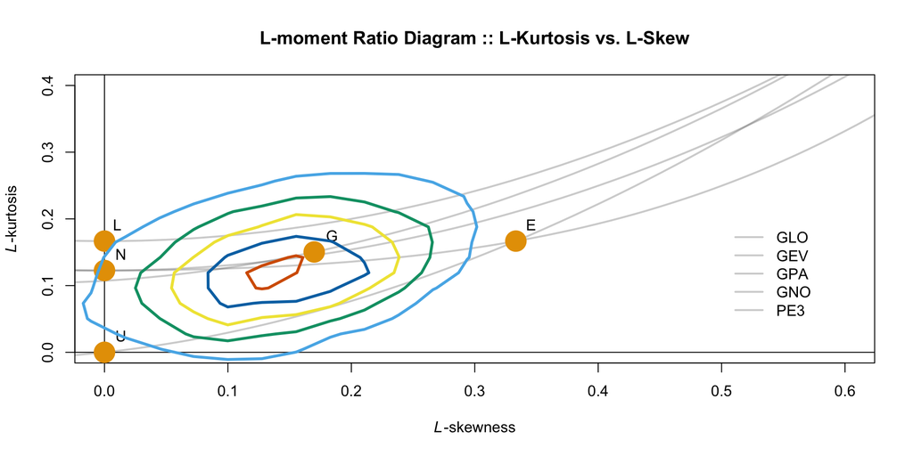

```r
  lmrd(main = "L-moment Ratio Diagram :: L-Kurtosis vs. L-Skew",
     lwd = 2, col = rep("#44444444", 10),
     pch.data = 19, cex.data = 0.1,
     pch.dist = 19, col.dist = "#E69F00", cex.dist = 3,
     xlegend = 0.5, ylegend=0.2)
  contour(d, drawlabels=FALSE, nlevels=7, lwd=3,
      col=c("#999999", "#56B4E9", "#009E73", "#F0E442", "#0072B2", "#D55E00", "#CC79A7"), add=TRUE)
```

## Brief Words on Hypothesis Testing

| Non-Exceedance Probability, PPCC Test, Gumbel Plot Pos. | Truth |  |  |  |
| --- | --- | --- | --- | --- |
| Hypothesis |  | Gamma | Weibull | Lognormal |
|  | Gamma | 0.05 | 0.08 | < 0.00 |
|  | Weibull | 0.22 | 0.05 | < 0.00 |
|  | Lognormal | 0.93 | 0.97 | 0.05 |

| Exceedance Probability, PPCC Test, Gumbel Plot Pos. | Truth |  |  |  |
| --- | --- | --- | --- | --- |
| Hypothesis |  | Gamma | Weibull | Lognormal |
|  | Gamma | 0.05 | 0.90 | 0.56 |
|  | Weibull | 0.99 | 0.05 | 0.99 |
|  | Lognormal | 0.99 | 0.99 | 0.05 |

## In Conclusion: my guess is GEV.